# Arima(order=c(1, 0, 0), seasonal=c(1, 0, 0), method=“ML”, xreg={ cbind(dummies = getNthObsDummies(5, 1, length(.), frequency(.)), fourier(., K = 2))}) on full 2hrs ph3

Barbu Paul - Gheorghe

# 1 Parameters

Series: **2hrs ph3**.

Model: **Arima(order=c(1, 0, 0), seasonal=c(1, 0, 0), method=“ML”, xreg={ cbind(dummies = getNthObsDummies(5, 1, length(.), frequency(.)), fourier(., K = 2))})**.

Transformation: **identity()**.

As observations: **FALSE**.

Train days: **7**.

Test days: **3**.

xreg: **{ cbind(dummies = getNthObsDummies(5, 1, h, frequency(.)), fourier(., h = h, K = 2))}**.

Parallel processing: **TRUE**.

# 2 Original data

The data has been previously cleaned, negative values were made 0.

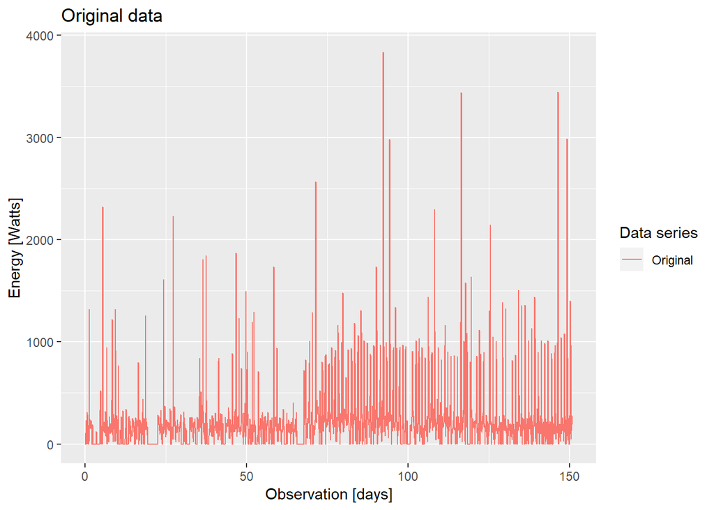

Total data points: **1811** representing **151** days.

Number of data points per day: **12** (gathered once every **120** minutes).

# 3 Forecast data

Time elapapsed for forecasting **144** days (representing 1728 data points), initial training data not taken into account: **6.17** seconds (**0.1028333** minutes).

## 3.1 Forecasts (un-adjusted) plot against the data

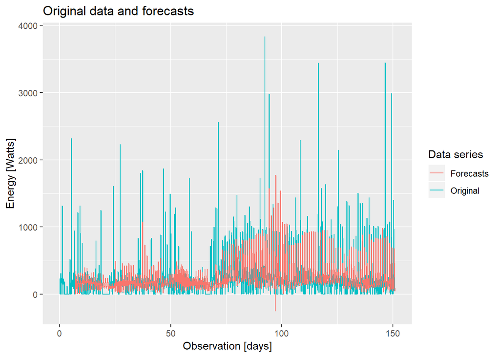

## 3.2 Accuracy of the un-adjusted forecasts against the data

|  | ME | RMSE | MAE | MPE | MAPE | ACF1 | Theil’s U |
| --- | --- | --- | --- | --- | --- | --- | --- |
| Test set | 5.165197 | 318.5324 | 180.0463 | -Inf | Inf | 0.1444346 | 0 |

## 3.3 Forecasts (adjusted) plot against the data

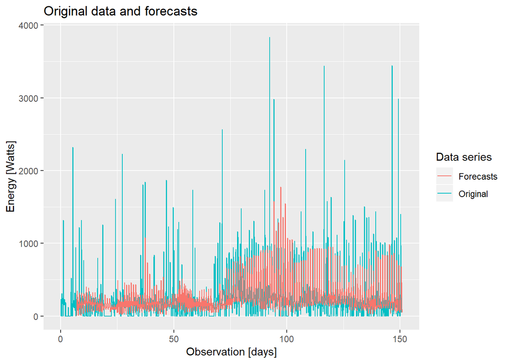

## 3.4 Accuracy of the adjusted forecasts against the data

|  | ME | RMSE | MAE | MPE | MAPE | ACF1 | Theil’s U |
| --- | --- | --- | --- | --- | --- | --- | --- |
| Test set | 5.020434 | 318.4172 | 179.9015 | -Inf | Inf | 0.1444757 | 0 |

# 4 Future work

- Some models (e.g. with fourier terms for the seasonality) may go into the negative values, this cannot be taken care of during the modelling/forecasting phase with these kind of models (since we cannot control the ampitude of the seasonality in each point) and would have to be corrected after forecasting in order to replace all negative values with zeros